# Datos univariados y su distribución

Felipe González

### Gráficas qq-normales

En las secciones anteriores hemos usado gráficas de cuantiles para graficar cuantiles de un conjunto de datos, cuantiles teóricos dada una función de distribución, y gráficas que comparan los cuantiles de dos conjuntos de datos. También es posible hacer gráficas de conjuntos de datos contra cuantiles teóricos de una distribución, de manera que podamos visualizar el grado de concordancia entre estas dos.

La más popular de estas gráficas son las *cuantil-cuantil normales* (*q-q normales*). Una manera de hacer estas gráficas para el conjunto de datos $x_1,...,x_n$ es calcular:

$\bar{x}=\frac{1}{n}\sum_{i=1}^n x_i, s=\sqrt{\frac{1}{n-1}\sum_{i=1}^n(x_i-\mu)^2}$

y calcular los cuantiles $q_{\bar{x},s}(f)$ de la distribución $Normal(\bar{x},s)$. Entonces calculamos $q_{\bar{x},s}(f)$ donde $f_1,f_2,...,f_n$ son los cuantiles de los datos y graficamos $(x_{i},q_{\bar{x},s}(f_i))$. Si los puntos no se desvían mucho de la recta $x=y$, entonces el conjunto de datos se distribuye, aproximadamente, de manera normal. Las desviaciones de la recta se interpretan como arriba hicimos con la gráfica cuantil cuantil.

Cuando queremos evaluar si la forma de la distribución de los datos es cercana a la normal, no es necesario calcular $\bar{x}$ y $s$, pues para cualquier $\mu$ y $\sigma$ tenemos que:

$q_{\mu, \sigma}(f) = \sigma q_{0,1}(f)+\mu,$

lo que implica que si graficamos los cuantiles $q_{0,1}(f_i)$ contra los del conjunto de datos, los datos se distribuyen aproximadamente normal cuando están dispuestos cerca de una recta.

**Construcción de una gráfica normal de cuantiles.** Si los datos ordenados están dados por $x_{1},x_{2},...,x_{n}$, con valores $f$ correspondientes $f_1,f_2,...,f_n$, entonces graficamos los puntos $(q_{0,1},x_{i})$.

#### Ejemplo: cantantes

En estas gráficas podemos ver:

1. Cada conjunto de datos es razonablemente bien aproximado por una distribución normal. Muchas de las desviaciones que observamos se deben a redondeo.
2. Aunque las medianas varían de grupo a grupo, las pendientes no varían mucho, esto quiere decir que las dispersiones (por ejemplo, desviaciones estándar) son similares a lo largo de todos los grupos.
3. La variación en la dispersión de cada conjunto de datos no está asociado a la mediana de cada uno.

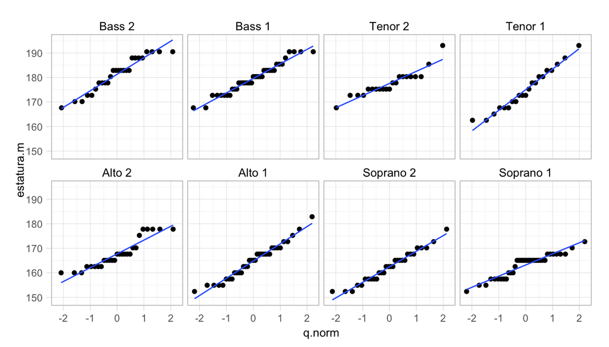

```r
library(ggplot2)
library(lattice)
library(dplyr)
# calculamos la estatura en centímetros
singer$estatura.m <- singer$height * 2.54

# calculamos el valor f dentro de cada grupo
singer_ord <- arrange(group_by(singer, voice.part), estatura.m)
singer_cuant <- mutate(singer_ord,
  n = n(),
  valor.f = (1:n[1] - 0.5)/n[1],
  q.norm = qnorm(valor.f)
  )

ggplot(singer_cuant, aes(x = q.norm, y = estatura.m)) +
  geom_point() +
  facet_wrap(~voice.part, nrow = 2) +
  geom_smooth(method = "lm", se = FALSE)
```

Esto sugiere una manera eficiente de describir los datos: en primer lugar, hemos detectado que hay cierta variación *espuria* (que seguramente no se repetiría si consideráramos otra muestra de cantantes, y si tuviéramos mediciones no redondeadas de las estaturas): el efecto del redondeo, y cierta variación no reproducible asociada con el hecho de que sólo estamos considerando una muestra de cantantes. No hay mucho que aprender de estos aspectos de los datos. En segundo lugar, hemos detectado patrones de variación que aparentan ser mucho más estables, como: 1) la distribución aproximadamente normal de las estaturas dentro de cada grupo, 2) La diferencia en la media de las distribuciones y 3) la similitud de la dispersión de cada grupo.

Proponemos una estructura para realizar una buena descripción final (concisa y que captura los aspectos más importantes) de los datos:

1. Podemos usar las medias para resumir el valor central de cada grupo de datos (no encontramos muchos valores atípicos ni asimetría importante). En nuestro caso obtenemos (redondeando a enteros):

```r
summarise(singer_ord, media = round(mean(estatura.m)))
```

```
Source: local data frame [8 x 2]

  voice.part media
1     Bass 2   181
2     Bass 1   180
3    Tenor 2   178
4    Tenor 1   175
5     Alto 2   168
6     Alto 1   165
7  Soprano 2   162
8  Soprano 1   163
```

2. Podemos usar la desviación estándar para resumir la dispersión en cada grupo (también por la simetría aproximada y el hecho de que no hay valores faltantes).

```r
summarise(singer_ord, media = round(sd(estatura.m)))
```

```
Source: local data frame [8 x 2]

  voice.part media
1     Bass 2     7
2     Bass 1     6
3    Tenor 2     5
4    Tenor 1     8
5     Alto 2     6
6     Alto 1     7
7  Soprano 2     6
8  Soprano 1     5
```

Más aún como las desviaciones estándar son muy similares, podemos resumir esta variación con un sólo número: *a partir de la media, en cada grupo, la estatura de los cantantes varía según una distribución normal con media cero y desviación estándar fija (que no depende del grupo) alrededor de 6.5 centímetros.

3. Los datos dentro de cada grupo tienen forma aproximadamente normal.
4. Finalmente, podemos señalar la existencia de dos datos potencialmente atípicos (en Tenor 2 y quizá Alto 1), y el hecho de que estos datos presentan evidencia fuerte de redondeo.

Este es nuestro primer ejemplo completo de análisis exploratorio, hemos:

- descubierto patrones y regularidades interesantes,
- logrado una descripción clara y concisa de los aspectos importantes,
- y además nos hemos puesto en una buena posición para hacer inferencia más adelante.

La idea es dar énfasis a las cosas más importantes, añadir algunos aspectos relevantes pero menos importantes (como el redondeo), e ignorar variación a escalas más chicas y aspectos que no tienen importancia (como que un cantante particular mide 1.83, etc).

Nótese que un punto importante de nuestra descripción fue utilizar la distribución normal para condensar nuestros hallazgos.

**La aproximación normal.** Cuando las distribuciones que nos interesan pueden aproximarse bien con la distribución normal, tenemos los siguientes aspectos positivos:

- La pregunta de si las distintas distribuciones son versiones desplazadas unas de las otras se convierte simplemente en preguntar si las desviaciones estándar son iguales o no. Esto lo podemos leer en la pendiente de las gráficas qq normales.
- Los métodos de ajuste e inferencia probabilística son simples y bien conocidos. Los estimadores $\bar{x}$ y $s$ son buenos estimadores de tendencia central y dispersión.
- La descripción de los datos es parsimoniosa, y sólo utiliza la media de cada grupo y un parámetro de dispersión (si las desviaciones estándar son iguales). Estos son suficientes para describir los aspectos importantes de los datos (en lugar de tener que considerar siempre el histograma completo de cada grupo).
- Es fácil calcular rangos aproximados de 95% y 68%.

## Ajustes y Residuales

En esta parte describimos una manera de entender lo que hicimos en la sección anterior.

Retomando el ejemplo de los cantantes, si $y_{pi}$ es la i-ésima estatura medida en el grupo (tesitura) $p$, entonces la estatura se descompone en dos partes: $y_{pi}=\bar{y}_p+\hat{\epsilon}_{pi},$

donde $\bar{y}_p$ es la estatura media dentro del grupo $p$.

Los residuales $\hat{\epsilon}_{pi}$ son las desviaciones de cada estatura con respecto a la media de su grupo:

$\hat{\epsilon}_{pi}= y_{pi}-\bar{y}_p$

que podemos escribir de manera simple como:

Valor observado = Valor ajustado + Residual

1. Los valores ajustados (las medias en este caso) **explican la variación en las estaturas que se puede atribuir a la tesitura de los cantantes**. Esta es variación entre grupos.
2. Los residuales **representan la variación de las estaturas dentro de cada tesitura,** que queda una vez que hemos quitado el desplazamiento de las medias a lo largo de las tesituras. Esta es variación **dentro de grupos.**

Podemos graficar las medias:

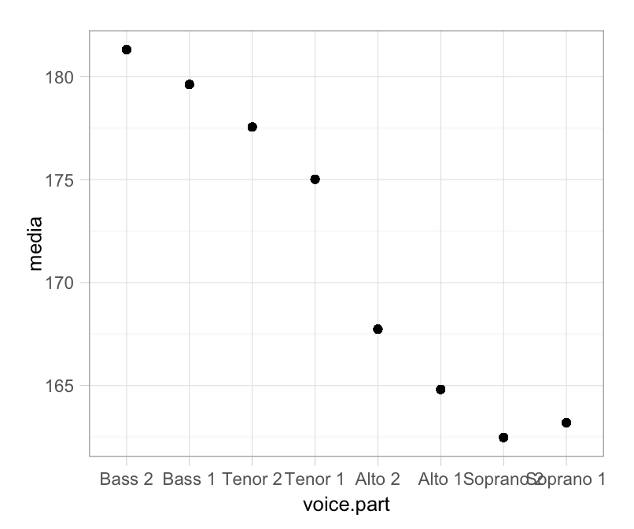

```r
singer_ajuste <- mutate(singer_ord,
  media = mean(estatura.m),
  residual = estatura.m - media,
  mediana = median(estatura.m),
  mediana_residual = median(residual))

ggplot(singer_ajuste, aes(x = voice.part, y = media)) +
  geom_point()
```

También podemos graficar los residuales dentro de cada tesitura. Primero calculamos las medias y a cada estatura le restamos la media del grupo que le corresponde.

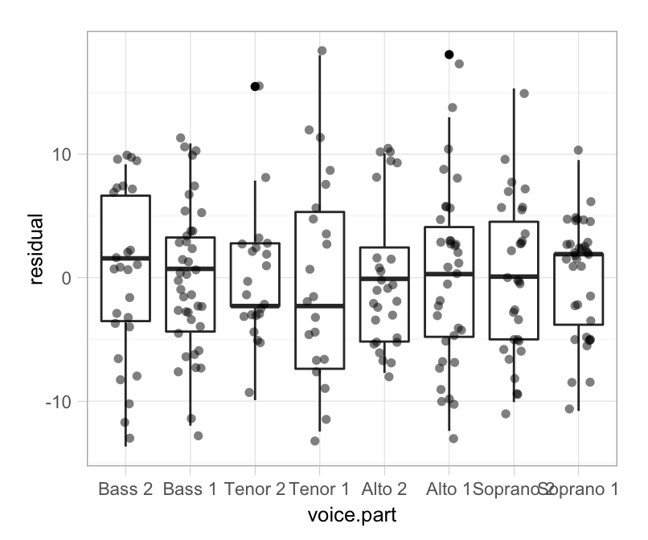

```r
ggplot(singer_ajuste, aes(x = voice.part, y = residual)) +
  geom_boxplot() +
  geom_jitter(position = position_jitter(height = 1, width = 0.2), alpha = 0.5 )
```

Que contrastamos con la gráfica correspondiente para las estaturas:

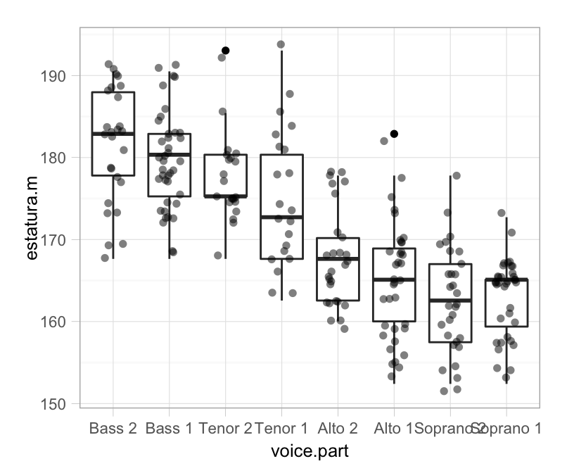

```r
ggplot(singer, aes(x = voice.part, y = estatura.m)) +
  geom_boxplot() +
  geom_jitter(position = position_jitter(height = 1, width = 0.2), alpha = 0.5 )
```

Con este tipo de análisis buscamos ir separando y entendiendo distintos aspectos o fuentes de variación en los datos. Primero reconocemos que las medias cambian de grupo a grupo. Entonces restamos las medias para *quitar* este efecto de los grupos. Hacemos esto para entonces estudiar con más facilidad la *variación que queda* después de quitar la fuente de variación que ya entendimos (unos grupos son más altos que otros).

#### Ejemplo:propinas

Consideremos el ejemplo de las propinas, nos interesa la pregunta: ¿Hombres y mujeres dan propina de manera distinta?

Comencemos con una gráfica de caja y brazos:

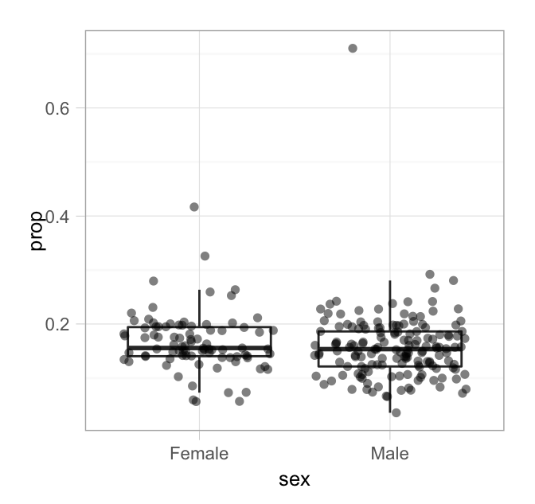

```r
library(reshape2)
tips$prop <- tips$tip/tips$total_bill
ggplot(tips, aes(x = sex, y = prop)) +
    geom_boxplot(outlier.size = 0) +
  geom_jitter(alpha = 0.5)
```

Donde vemos, en primer lugar, que hay varias proporciones grandes que ocurren para hombres y mujeres. Estas distribuciones no son simétricas sino que están sesgadas a la derecha.

Las medianas, son similares y ambas ligeramente mayores a 15%.

```r
summarise(group_by(tips, sex),
  mediana_prop = median(prop)
  )
```

```
Source: local data frame [2 x 2]

     sex mediana_prop
1 Female       0.1556
2   Male       0.1535
```

Calculamos los residuales tomando a la mediana como valor ajustado en cada grupo:

```r
tips_ajuste <- mutate(group_by(tips, sex),
  mediana_prop = median(prop),
  residual = prop - mediana_prop
  )
tips_ajuste
```

```
Source: local data frame [244 x 10]
Groups: sex

   total_bill  tip    sex smoker day   time size    prop mediana_prop
1       16.99 1.01 Female     No Sun Dinner    2 0.05945       0.1556
2       10.34 1.66   Male     No Sun Dinner    3 0.16054       0.1535
3       21.01 3.50   Male     No Sun Dinner    3 0.16659       0.1535
4       23.68 3.31   Male     No Sun Dinner    2 0.13978       0.1535
5       24.59 3.61 Female     No Sun Dinner    4 0.14681       0.1556
6       25.29 4.71   Male     No Sun Dinner    4 0.18624       0.1535
7        8.77 2.00   Male     No Sun Dinner    2 0.22805       0.1535
8       26.88 3.12   Male     No Sun Dinner    4 0.11607       0.1535
9       15.04 1.96   Male     No Sun Dinner    2 0.13032       0.1535
10      14.78 3.23   Male     No Sun Dinner    2 0.21854       0.1535
..        ...  ...    ...    ... ...    ...  ...     ...          ...
Variables not shown: residual (dbl)
```

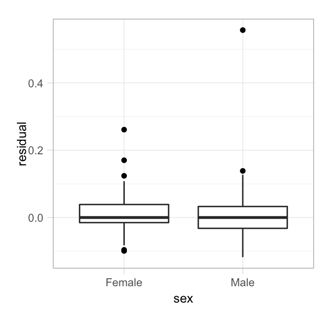

```r
ggplot(tips_ajuste, aes(x = sex, y = residual)) +
  geom_boxplot()
```

Y ahora comparamos las distribuciones con un qq-plot:

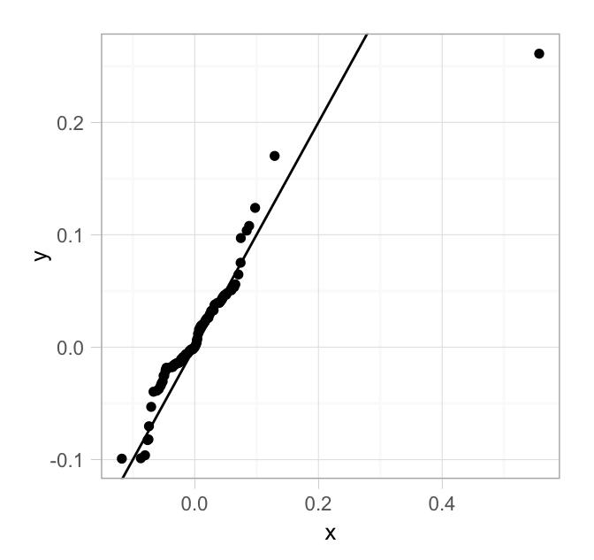

```r
hombres <- tips_ajuste$residual[tips_ajuste$sex == 'Male']
mujeres <- tips_ajuste$residual[tips_ajuste$sex == 'Female']

qq_sex <- qqplot(hombres, mujeres, plot.it = FALSE)
ggplot(as.data.frame(qq_sex), aes(x, y)) +
  geom_point() +
  geom_abline(intercept=0, slope = 1)
```

Notamos que estas distribuciones no son muy distintas, excepto por el atípico que observamos en hombres.

Por otra parte, en este ejemplo no es razonable usar el modelo normal para describir los residuales:

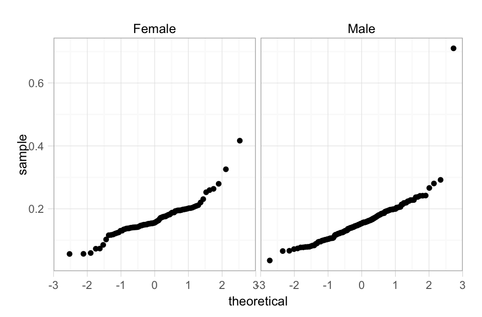

```r
ggplot(tips_ajuste, aes(sample = prop)) +
  stat_qq() +
  facet_wrap(~sex)
```

```r
# qq-plots normales en R base:
# qqnorm(mujeres)
# qqline(mujeres)
```

Una alternativa es usar cuantiles:

```r
summarise(group_by(tips, sex),
  cuarto_inf = round(quantile(prop, 0.25), 2),
  mediana = round(median(prop), 2),
  cuarto_sup = round(quantile(prop, 0.75), 2)
  )
```

```
Source: local data frame [2 x 4]

     sex cuarto_inf mediana cuarto_sup
1 Female       0.14    0.16       0.19
2   Male       0.12    0.15       0.19
```

Y podemos describir los datos como sigue:

- La mediana de la propina es un superior a 15 por ciento. Esto no depende del genero del que da la propina.
- En raras ocasiones, los clientes dejan propinas grandes (en proporción): mayor a 25% solo ocurre alrededor de un 4% de ocasiones, y hay un atípico de 70% (hombre).
- El 50% de las propinas típicas varía entre 13 y 19%, es decir, entre -2 y +4 puntos porcentuales a partir de 15%. La distribución es asimétrica (hay sesgo hacia arriba, lo cual hace emocionante recibir propinas!).

¿Por qué no logramos una descripción tan simple como la de los cantantes?